# PML Course Project

Ilmira Shaim

23 января 2015 г.

Loading and reading data

```r
if(!file.exists("pml-training.csv")){
    download.file("https://d396qusza40orc.cloudfront.net/predmachlearn/pml-training.csv",
                  destfile="pml-training.csv",
                  method="curl")
}
if(!file.exists("pml-testing.csv")){
    download.file("https://d396qusza40orc.cloudfront.net/predmachlearn/pml-testing.csv",
                  destfile="pml-testing.csv",
                  method="curl")
}
training <- read.csv("pml-training.csv")
testing <- read.csv("pml-testing.csv")
```

```r
trainingAdelmo = training[training$user_name=="adelmo",]
unique(trainingAdelmo[trainingAdelmo$classe=="A", c("cvtd_timestamp")])
```

```
## [1] 02/12/2011 13:32 02/12/2011 13:33
## 20 Levels: 02/12/2011 13:32 02/12/2011 13:33 ... 30/11/2011 17:12
```

```r
tAdelmoTimestamp1 <- trainingAdelmo$raw_timestamp_part_1[trainingAdelmo$classe=="A"]
length(tAdelmoTimestamp1)/length(unique(tAdelmoTimestamp1))
```

```
## [1] 21.98113
```

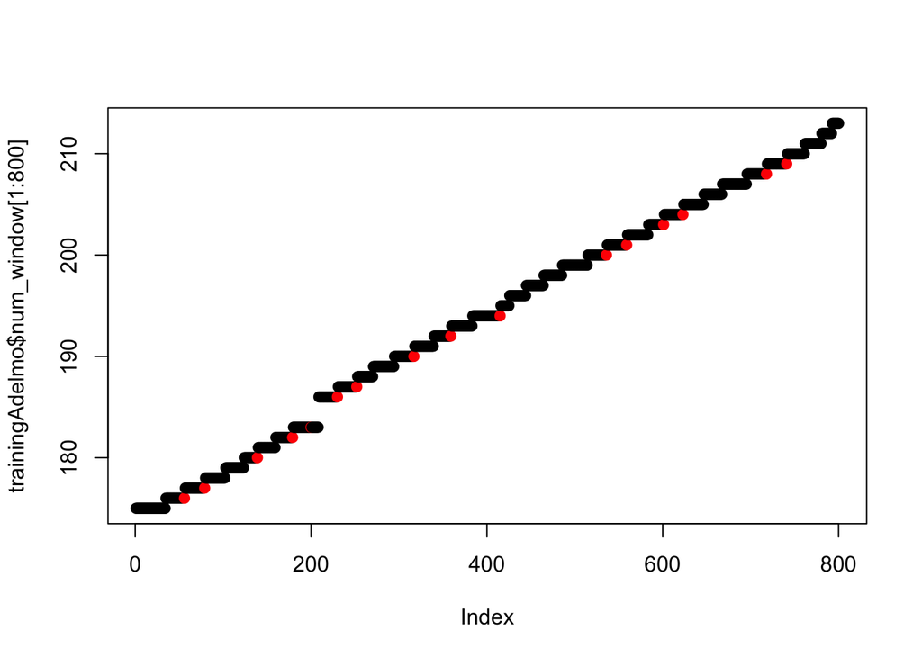

```r
plot(x=trainingAdelmo$num_window[1:800],col=trainingAdelmo$new_window[1:800],pch=19)
```

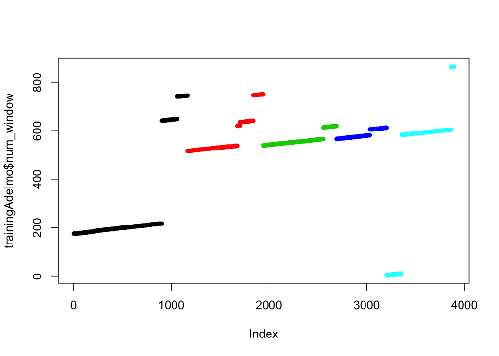

```r
plot(trainingAdelmo$num_window, col=(trainingAdelmo$classe), pch=20)
```

num_window mean probably the num of second

belt, arm, forearm, dumbell roll, pitch, yaw: kurtosis, skewness, max, min, amplitude, avg, stddev, var - 27 gyros, accel, magnet: x, y ,z - 9 total_accel, var_total_accel - 2

38*4 = 152 X, user_name, raw_timestamp_part_1 - number of seconds from 1970-01-01 raw_timestamp_part_2 - number of microseconds cvtd_timestamp - date new_window - yes/no num_window - second classe - [A, B, C, D, E]

Trying to understand in which groups min, max, avg etc. were calculated

```r
groupsAdelmo <- c(0, cumsum(trainingAdelmo$new_window=="yes")[1:length(trainingAdelmo$new_window)-1])
```

These “summary” values are messed up and there are no values in the test set, so we just remove them. belt, arm, forearm, dumbell roll, pitch, yaw - 3 gyros, accel, magnet: x, y ,z - 9 total_accel - 1

```r
training <- (subset(training,select = !names(training) %in% (grep("kurtosis|skewness|max|min|avg|amplitude|stddev|var", names(training), value=T))))
dim(training)
```

```
## [1] 19622    60
```

```r
library(caret)
library(randomForest)
train52 <- subset(training,select = !names(training) %in% c("X","user_name","raw_timestamp_part_1","raw_timestamp_part_2","cvtd_timestamp","new_window","num_window"))
```

Now we’ll use cross validation to select how many features we’ll use in random forest algorithm.

```r
res <- rfcv(train52[,-53], train52[,53], cv.fold=5, step = 0.5)
res$error.cv
```

```
##          52          26          13           6           3           1
## 0.004586688 0.005096320 0.007899297 0.039139741 0.105799613 0.593721333
```

Now let’s fit the model with random forest with default parameters and choose 13 most important variables

```r
modelFit <- randomForest(x = train52[,-53], y=train52$classe, importance=TRUE)
```

```r
imps <- importance(modelFit)[,c("MeanDecreaseGini")]
impVars <- names(imps)[order(imps, decreasing = T)][1:13]
train13 <-  subset(train52,select = names(train52) %in% c(impVars, "classe"))
```